# Geospatial Risk Prediction in Chicago IL

#### 0.4.0.5 Kernel Density

Finally, I will compare the performance of risk predictions with traditional ‘Kernel density’ hotspot mapping.

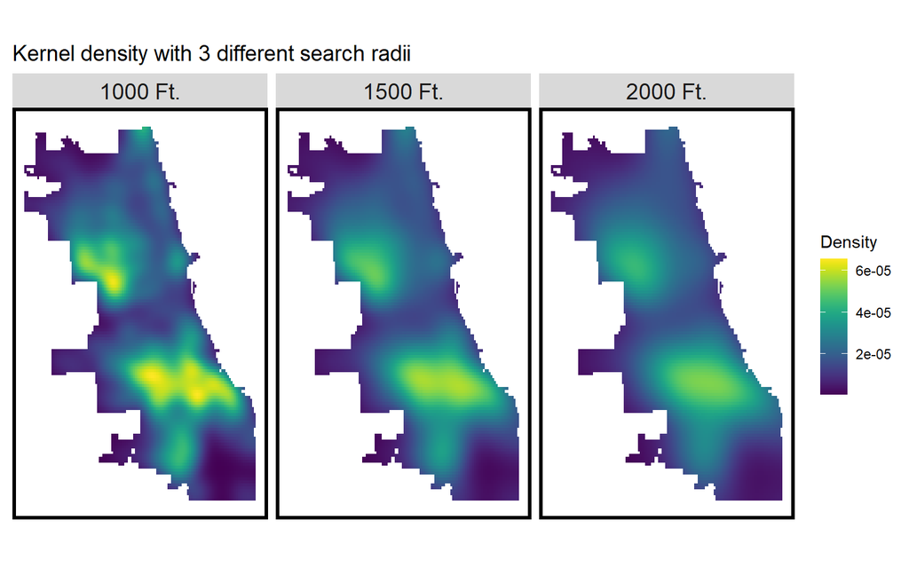

```r
# demo of kernel width
dam_ppp <- as.ppp(st_coordinates(Damages), W = st_bbox(final_net))
dam_KD.1000 <- spatstat.core::density.ppp(dam_ppp, 1000)
dam_KD.1500 <- spatstat.core::density.ppp(dam_ppp, 1500)
dam_KD.2000 <- spatstat.core::density.ppp(dam_ppp, 2000)
dam_KD.df <- rbind(
  mutate(data.frame(rasterToPoints(mask(raster(dam_KD.1000), as(neighborhoods, 'Spatial')))), Legend = "1000 Ft."),
  mutate(data.frame(rasterToPoints(mask(raster(dam_KD.1500), as(neighborhoods, 'Spatial')))), Legend = "1500 Ft."),
  mutate(data.frame(rasterToPoints(mask(raster(dam_KD.2000), as(neighborhoods, 'Spatial')))), Legend = "2000 Ft."))

dam_KD.df$Legend <- factor(dam_KD.df$Legend, levels = c("1000 Ft.", "1500 Ft.", "2000 Ft."))

ggplot(data=dam_KD.df, aes(x=x, y=y)) +
  geom_raster(aes(fill=layer)) +
  facet_wrap(~Legend) +
  coord_sf(crs=st_crs(final_net)) +
  scale_fill_viridis(name="Density") +
  labs(title = "Kernel density with 3 different search radii") +
  mapTheme(title_size = 14)
```

```r
as.data.frame(dam_KD.1000) %>%
  st_as_sf(coords = c("x", "y"), crs = st_crs(final_net)) %>%
  aggregate(., final_net, mean) %>%
   ggplot() +
     geom_sf(aes(fill=value)) +
     geom_sf(data = sample_n(Damages, 1500), size = .5) +
     scale_fill_viridis(name = "Density") +
     labs(title = "Kernel density of 2017 Criminal Property Damages") +
     mapTheme(title_size = 14)
```

[figure not shown]

##### 0.4.0.5.1 Get 2018 crime data

```r
Damages18 <-
  read.socrata("https://data.cityofchicago.org/Public-Safety/Crimes-2018/3i3m-jwuy") %>%
  filter(Primary.Type == "CRIMINAL DAMAGE" & Description == "TO PROPERTY") %>%
  mutate(x = gsub("[()]", "", Location)) %>%
  separate(x,into= c("Y","X"), sep=",") %>%
  mutate(X = as.numeric(X),
         Y = as.numeric(Y)) %>%
  na.omit %>%
  st_as_sf(coords = c("X", "Y"), crs = 4326, agr = "constant") %>%
  st_transform('ESRI:102271') %>%
  distinct() %>%
  .[fishnet,]
```

```r
dam_KDE_sum <- as.data.frame(dam_KD.1000) %>%
  st_as_sf(coords = c("x", "y"), crs = st_crs(final_net)) %>%
  aggregate(., final_net, mean)
kde_breaks <- classIntervals(dam_KDE_sum$value,
                             n = 5, "fisher")
dam_KDE_sf <- dam_KDE_sum %>%
  mutate(label = "Kernel Density",
         Risk_Category = classInt::findCols(kde_breaks),
         Risk_Category = case_when(
           Risk_Category == 5 ~ "5th",
           Risk_Category == 4 ~ "4th",
           Risk_Category == 3 ~ "3rd",
           Risk_Category == 2 ~ "2nd",
           Risk_Category == 1 ~ "1st")) %>%
  cbind(
    aggregate(
      dplyr::select(Damages18) %>% mutate(damCount = 1), ., sum) %>%
    mutate(damCount = replace_na(damCount, 0))) %>%
  dplyr::select(label, Risk_Category, damCount)
```

```r
dam_risk_sf <-
  filter(reg.summary, Regression == "Spatial LOGO-CV: Spatial Process") %>%
  mutate(label = "Risk Predictions",
        Risk_Category = classInt::findCols(kde_breaks),
         Risk_Category = case_when(
           Risk_Category == 5 ~ "5th",
           Risk_Category == 4 ~ "4th",
           Risk_Category == 3 ~ "3rd",
           Risk_Category == 2 ~ "2nd",
           Risk_Category == 1 ~ "1st")) %>%
  cbind(
    aggregate(
      dplyr::select(Damages18) %>% mutate(damCount = 1), ., sum) %>%
      mutate(damCount = replace_na(damCount, 0))) %>%
  dplyr::select(label,Risk_Category, damCount)
```

```r
rbind(dam_KDE_sf, dam_risk_sf) %>%
  na.omit() %>%
  gather(Variable, Value, -label, -Risk_Category, -geometry) %>%
  ggplot() +
    geom_sf(aes(fill = Risk_Category), colour = NA) +
    geom_sf(data = sample_n(Damages18, 3000), size = .5, colour = "black") +
    facet_wrap(~label, ) +
    scale_fill_viridis(discrete = TRUE) +
    labs(title="Comparison of Kernel Density and Risk Predictions",
         subtitle="2017 Property Damage Risk Predictions; 2018 Damaged Properties") +
    mapTheme(title_size = 14)
```

[figure not shown]

While there are areas where the high density of observed property damage overlays high-risk categories, some of the density also occur in lower-risk categories which may suggest latent risk or a poorly fit model.

```r
rbind(dam_KDE_sf, dam_risk_sf) %>%
  st_drop_geometry() %>%
  na.omit() %>%
  gather(Variable, Value, -label, -Risk_Category) %>%
  group_by(label, Risk_Category) %>%
  summarize(damCount = sum(Value)) %>%
  ungroup() %>%
  group_by(label) %>%
  mutate(Pcnt_of_test_set_crimes = damCount / sum(damCount)) %>%
    ggplot(aes(Risk_Category,Pcnt_of_test_set_crimes)) +
      geom_bar(aes(fill=label), position="dodge", stat="identity") +
      scale_fill_viridis(discrete = TRUE, name = "Model") +
      labs(title = "Risk Prediction vs. Kernel Density, 2018 Damaged Properties",
           y = "% of Test Set Damaged Properties (per model)",
           x = "Risk Category") +
  theme_bw() +
      theme(axis.text.x = element_text(angle = 45, vjust = 0.5))
```

[output not shown]

## 0.5 Conclusion

I would not recommend my algorithm to predict the risk of criminal property damage in Chicago for the following reasons. The model is limited to the reported cases of damaged property which implies that we do not see the full picture. The predictions may be inclined toward the areas with previously reported cases. Additionally, the spatial risk factors selected in this model were limited in their ability to predict property damage. A more robust selection of spatial risk factors could improve the performance of this model.

However, even if we assume that all cases of criminal property damage were reported, the accuracy of the predictions could still be questioned. Unlike crimes such as robbery whose potential risk may be influenced by the area the person is in, property damage is often connected to other crimes or is targeted at a particular person. In that case, the location of the house does not necessarily determine if a house would be damaged.

Finally, models like this one used in predictive policing can produce dangerous outcomes in our communities. Even without the indenting to, they can reproduce systems of discrimination that manifest in the way we police black and Brown neighborhoods. They could be better adapted to other uses by the public sector.